# HW06：Working with Strings

YI YIN

2018-10-29

# 1. Words in Ulysses

## a) Words with z

Select all unique words that contain at least one z.

```r
z_words <- words$word%>%str_subset("z")%>%unique()
```

Among the z-words, tabulate how many z’s the words contain (i.e. how many words contain one z, two z’s etc.).

```r
z_words%>%str_count("z")%>%table()
```

```
## .
##   1   2   3
## 293  46   1
```

Find the z-word(s) with z’s that are as far apart as possible (i.e. we are interested in the distance between two z’s in the word. That means the word could contain more than two z’s.).

```r
z_2more <- z_words%>%
        str_split("z", simplify = TRUE) %>%
        as_tibble() %>%
        cbind(z_words)%>%
        rename(full_word = z_words)%>%
        filter(V3!="")%>%
        mutate(z1_z2 = nchar(V2))%>%
        mutate(z2_z3 = ifelse(V4 =="", NA, nchar(V3)))%>%
        mutate(z1_z3 =  ifelse(V4 =="", NA,
                               nchar(V2)+nchar(V3)))

# Max distance between first z and second z
z_2more%>%top_n(1, z1_z2)
```

```
##   V1 V2     V3 V4  full_word z1_z2 z2_z3 z1_z3
## 1    ig agging    zigzagging     2    NA    NA
## 2    ig     ag        zigzag     2    NA    NA
## 3    ig    ags       zigzags     2    NA    NA
```

```r
# Max distance between second z and third z
z_2more%>%top_n(1, z2_z3)
```

```
##   V1 V2      V3          V4               full_word z1_z2 z2_z3 z1_z3
## 1  s  á harminc brojúgulyás százharminczbrojúgulyás     1     7     8
```

```r
# Max distance between first z and third z
z_2more%>%top_n(1, z1_z3)
```

```
##   V1 V2      V3          V4               full_word z1_z2 z2_z3 z1_z3
## 1  s  á harminc brojúgulyás százharminczbrojúgulyás     1     7     8
```

**Therefore, `százharminczbrojúgulyás` is the word with largest distance between “z”s.**

2. Vowels How many unique words start and end with a vowel?

**– 876 words start and end with a vowel?**

```r
v_words <- words$word%>%str_subset("^[aeiou].*[aeiou]$")%>%unique()
length(v_words)
```

```
## [1] 876
```

Are there words that start with two or more vowels?

**– 72 words start with two or more vowels and end with a vowel.**

```r
words$word%>%str_subset("^[aeiou]{2,}")%>%unique()%>%length()
```

```
## [1] 341
```

**– 341 words start with two or more vowels.**

```r
v_words%>%str_subset("^[aeiou]{2,}")%>%unique()%>%length()
```

```
## [1] 72
```

Find and display the word(s) with the most consecutive vowels (anywhere in the word).

– `frseeeeeeeeeeeeeeeeeeeefrong` is the word with the most consecutive vowels.

```r
c_vowels <- words$word%>%
        str_extract_all("[aeiou]{2,}",
                        simplify = TRUE)%>%
        as_tibble() %>%
        cbind(words$word)%>%
        mutate(l1 = nchar(V1))%>%
         mutate(l2 = nchar(V2))%>%
                 mutate(l3 = nchar(V3))%>%
                  mutate(l4 = nchar(V4))%>%
                 mutate(l5 = nchar(V5))%>%
                 mutate(l6 = nchar(V6))

# find the max number of consecutive vowels
map_dbl(c_vowels[,8:13], max)
```

```
## l1 l2 l3 l4 l5 l6
## 20  7  3  2  2  2
```

```r
c_vowels%>% filter(l1 == 20)%>%select(`words$word`)
```

```
##                     words$word
## 1 frseeeeeeeeeeeeeeeeeeeefrong
```

3. English spelling Empirically verify the rule “i before e except after c”. No need to become a linguist here; simply tabulate the proportion of words when the rule holds and when it does not.

```r
eng <- words$word%>%
        str_subset("(^ie)|[abd-z]ie|cei")%>%
        unique()

eng_n <- words$word%>%str_subset("(^ei)|[abd-z]ei|cie")%>%
        unique()

eng_spell <- matrix(c(length(eng), length(eng_n)), 1)
colnames(eng_spell) <- c( 'English spelling', "Not English spelling")
prop.table(eng_spell)*100
```

```
##      English spelling Not English spelling
## [1,]         78.41021             21.58979
```

# 2. MTA Delays

## a) Reduce the data

```r
rm(list = ls())
mta <- read_rds("mta.RDS")

data <-mta%>%filter(is_retweet == FALSE,
                    str_detect(text, "^@.*") == FALSE)%>%
        select(text, created_at)
```

## b) Time of Delay

Pattern: XX trains are running with delays because of xx problems.

```r
library(lubridate)
library(tidyverse)
timed <- data%>%
        filter(str_detect(text, "trains are running with delays") == TRUE)%>%
        mutate(w_day = wday(created_at, label = T),
               clock = lubridate::hour(created_at))%>%mutate(period=
    case_when(
      between(clock, 6, 9) ~ "mornings",
       between(clock, 10, 14) ~ "mid-day",
       between(clock, 15, 17) ~ "afternoon",
      between(clock, 18, 21) ~ "evening",
      between(clock, 22, 24) ~ "night",
      between(clock, 0, 5) ~ "night"
    ))
```

Provide a table that shows delays by day of the week and time of day. Use the following time periods: mornings (6-10), mid-day (10-15), afternoon (15 - 18), evening (18- 22), and night (22 - 24; 0-6). What do you find?

### Delays by day of the week

```r
timed%>%group_by(w_day)%>%summarise(n=n())
```

```
## # A tibble: 7 x 2
##   w_day     n
##   <ord> <int>
## 1 Sun     423
## 2 Mon     564
## 3 Tue     486
## 4 Wed     485
## 5 Thu     464
## 6 Fri     469
## 7 Sat     384
```

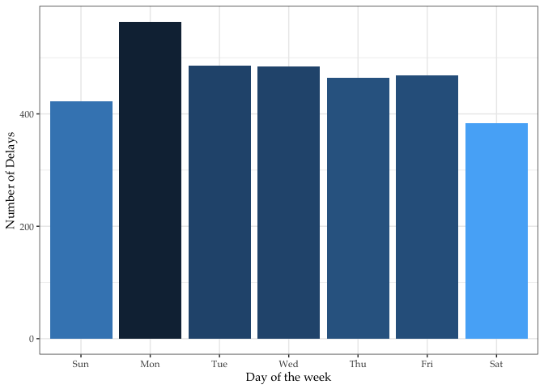

### Delays by and time of day

```r
timed$period <- factor(timed$period, ordered = TRUE,
                    levels = c("mornings",
                               "mid-day",
                               "afternoon",
                               "evening",
                               "night"))

timed%>%group_by(period)%>%summarise(n=n())
```

```
## # A tibble: 5 x 2
##   period        n
##   <ord>     <int>
## 1 mornings    259
## 2 mid-day    1003
## 3 afternoon   466
## 4 evening     739
## 5 night       808
```

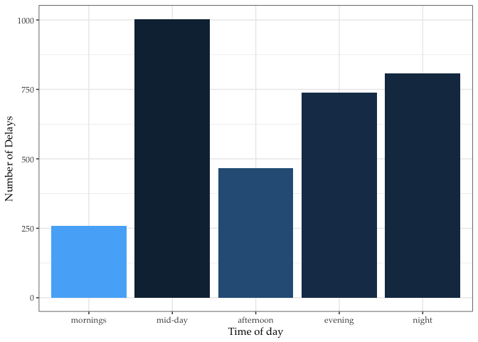

## c) Type of Delay

Among the set of tweets in part b), try to categorize the types of delays. No need to be exhaustive but try to pick up the top 3-5 reasons for delays.

```r
typed <- timed$text%>%
        str_split("because of", n= 2, simplify = TRUE)%>%
        .[,2]%>%word(1, 4)%>%
        as_tibble()%>%
        rename(reason = value)



typed%>%filter(is.na(reason) == F )%>%
        group_by(reason)%>%
        summarise(n = n())%>%
        top_n(20, n)%>% arrange(desc(n))
```

```
## # A tibble: 20 x 2
##    reason                           n
##    <chr>                        <int>
##  1 " signal problems at"          960
##  2 " a train with"                466
##  3 " a sick passenger"            160
##  4 " NYPD activity at"            159
##  5 " switch problems at"          150
##  6 " a passenger in"              115
##  7 " a customer in"                77
##  8 " an unauthorized person"       66
##  9 " track maintenance at"         65
## 10 " an NYPD investigation"        60
## 11 " FDNY activity at"             51
## 12 " an investigation at"          42
## 13 " an unruly passenger"          35
## 14 " track maintenance between"    33
## 15 " a signal problem"             32
## 16 " signal problems between"      29
## 17 " a rail condition"             27
## 18 " a switch problem"             23
## 19 " an injured passenger"         23
## 20 " a train's brakes"             19
```

Combine them into reasonable categories if necessary (e.g. signal problems, medical, technical problems, etc.). Provide an overview (table or graph) of which types of delays are most common.

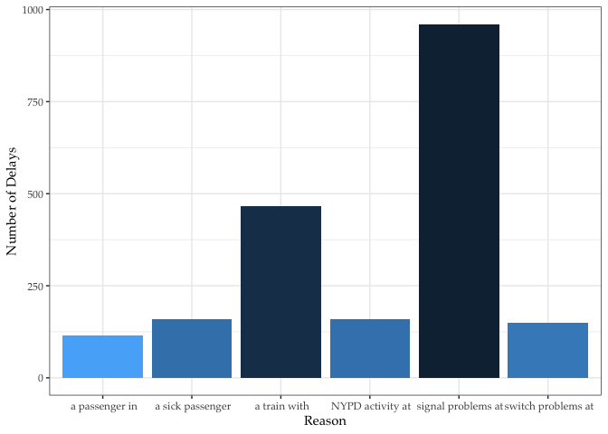

```r
typed%>%filter(is.na(reason) == F )%>%
        group_by(reason)%>%
        summarise(n = n())%>%
        top_n(6, n)%>% arrange(desc(n))%>%
        ggplot(aes(reason,n ,fill = 1/n))+
        geom_bar(stat="identity")+
        xlab('Reason')+
        ylab('Number of Delays')+
        theme_bw(base_family = 'Palatino')+
        theme(legend.position="none")
```

## d) Which train lines affected?

Write a regex pattern that captures which train lines are affected by delays.

```r
lined <- timed%>%select(text, w_day)%>% mutate(train = str_extract(text,
                                  "(.*)(?= train[s]* are)"))

lined <- lined%>%
        mutate(train_s = str_remove_all(train,
                                        ".*bound[\\b\\s]"))%>%
        mutate(weekend = ifelse(w_day %in% c("Sun", "Sat"),
                                "weekend",
                                "weekday"))


lines <-lined%>% select(train_s, weekend)%>%
        mutate(line = str_remove_all(train_s, "\\b[A-Za-z]{2,}\\b")%>%
        str_remove_all("[^A-Z0-9]")%>%
        str_replace_all('([A-Z0-9])\\1+', '\\1'))%>%
        select(-train_s)%>%
        mutate(i = row_number())

# max(map_dbl(lines$line, nchar))
# lines$i[nchar(lines$line) == 8]

line_n <- paste0("line", 1:8)

library(reshape2)

lines <- cbind(reshape2::colsplit(lines$line, "", names = line_n),
               lines[,3], lines[,1])

tidy <- lines %>%
  reshape2::melt(variable.name = "note",
                 value.name = "train",
                 id.vars = c("i", 'weekend'))
```

Provide a summary of which train lines are affected by weekday vs. weekend.

```r
plot<-tidy%>%filter(train !="")%>%
        select(train,weekend)%>%
        group_by(train,weekend)%>%summarise(n = n())%>%
        mutate(weekend, percent = paste0(sprintf("%1.1f",
                                          n/sum(n)*100),"%"))

plot
```

```
## # A tibble: 46 x 4
## # Groups:   train [24]
##    train weekend     n percent
##    <chr> <chr>   <int> <chr>
##  1 1     weekday   144 70.2%
##  2 1     weekend    61 29.8%
##  3 2     weekday   288 75.0%
##  4 2     weekend    96 25.0%
##  5 3     weekday   182 78.1%
##  6 3     weekend    51 21.9%
##  7 4     weekday   193 71.5%
##  8 4     weekend    77 28.5%
##  9 5     weekday   216 76.9%
## 10 5     weekend    65 23.1%
## # ... with 36 more rows
```

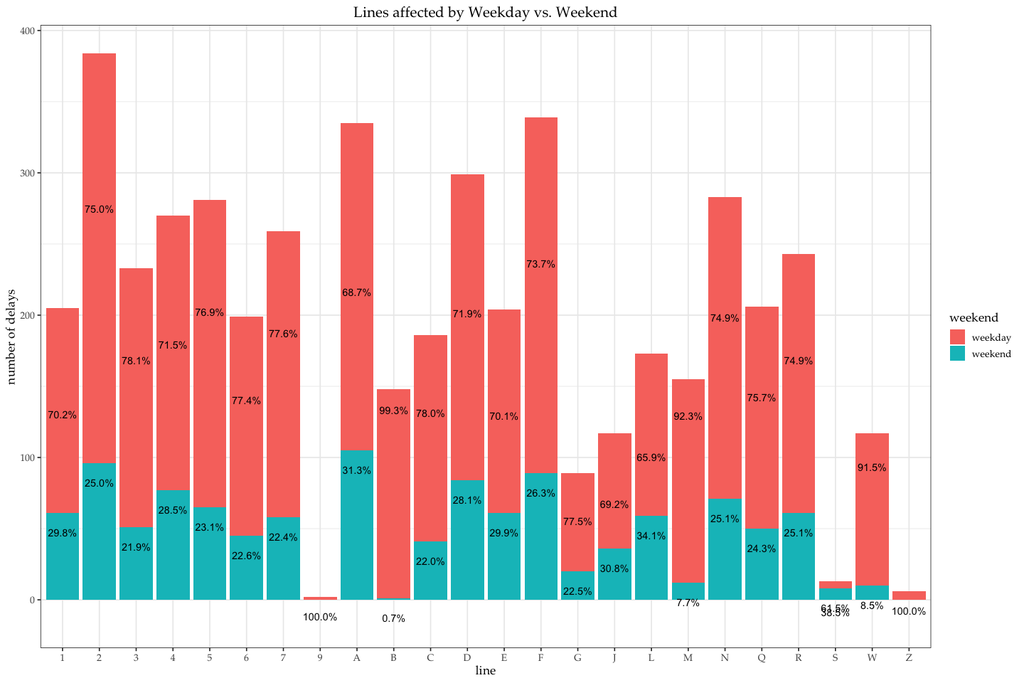

```r
ggplot(plot, aes(train, n, fill= weekend))+
        geom_bar(stat="identity") +
        geom_text(aes(label=percent, y=n-15), size = 3.8,
                  vjust=0.2)+
        ylab("number of delays")+ xlab("line")+
        ggtitle('Lines affected by Weekday vs. Weekend')+
        theme_bw(base_family = "Palatino", base_size = 13)+
        theme(plot.title = element_text(hjust = 0.5))
```